# 04_describe

## Aim

This document describes the distribution of BrainSpan RNA-seq samples across developmental age groups in the hippocampus and dorsolateral prefrontal cortex (DLPFC).

## Load libraries and read augmented data

We read the augmented data saved by `03_augment.qmd`. The table contains one row per gene and sample, along with the developmental age group assigned to each sample.

```r
library(tidyverse)
library(here)

expr_aug <- read_tsv(
  file = here("data", "03_dat_aug.tsv"),
  show_col_types = FALSE
)
```

## Create a sample metadata table

We retain samples from the hippocampus and DLPFC. In these data, each combination of donor ID and brain region identifies one sample. Since the same sample appears on multiple gene rows, we keep each combination of donor ID, brain region, and age group once. The resulting table contains 67 samples.

```r
sample_metadata <- expr_aug |>
  filter(
    structure_name %in% c(
      "hippocampus (hippocampal formation)",
      "dorsolateral prefrontal cortex"
    )
  ) |>
  distinct(donor_id, structure_name, age_group)

nrow(sample_metadata)
```

```
[1] 67
```

## Count samples by brain region and age group

We count samples in each combination of brain region and developmental age group. This shows how well each developmental stage is represented in the two regions.

```r
sample_counts <- sample_metadata |>
  count(structure_name, age_group, name = "n_samples")

sample_counts
```

```
# A tibble: 10 × 3
   structure_name                      age_group  n_samples
   <chr>                               <chr>          <int>
 1 dorsolateral prefrontal cortex      Adolescent         3
 2 dorsolateral prefrontal cortex      Adult              5
 3 dorsolateral prefrontal cortex      Child              6
 4 dorsolateral prefrontal cortex      Infant             4
 5 dorsolateral prefrontal cortex      Prenatal          17
 6 hippocampus (hippocampal formation) Adolescent         3
 7 hippocampus (hippocampal formation) Adult              6
 8 hippocampus (hippocampal formation) Child              5
 9 hippocampus (hippocampal formation) Infant             3
10 hippocampus (hippocampal formation) Prenatal          15
```

## Visualise sample counts across developmental stages

We plot the number of samples in each developmental age group for the hippocampus and dorsolateral prefrontal cortex (DLPFC).

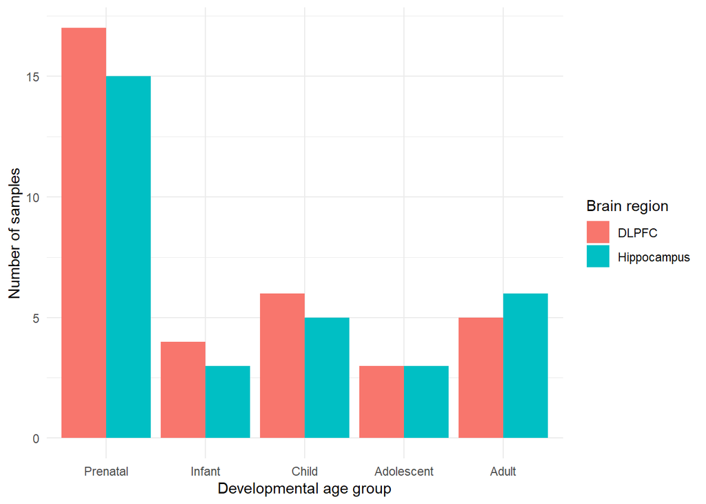

Number of BrainSpan samples by developmental age group and brain region.

```r
sample_counts |>
  mutate(
    age_group = factor(
      age_group,
      levels = c("Prenatal", "Infant", "Child", "Adolescent", "Adult")
    ),
    brain_region = recode(
      structure_name,
      "hippocampus (hippocampal formation)" = "Hippocampus",
      "dorsolateral prefrontal cortex" = "DLPFC"
    )
  ) |>
  ggplot(aes(x = age_group, y = n_samples, fill = brain_region)) +
  geom_col(position = "dodge") +
  labs(
    x = "Developmental age group",
    y = "Number of samples",
    fill = "Brain region"
  ) +
  theme_minimal()
```

## Check donor overlap between brain regions

We count the number of donors with samples from both brain regions. These donors can be included in a paired comparison of the hippocampus and DLPFC.

```r
donor_coverage <- sample_metadata |>
  group_by(donor_id) |>
  summarise(
    n_regions = n_distinct(structure_name),
    .groups = "drop"
  )

donor_coverage |>
  count(n_regions, name = "n_donors")
```

```
# A tibble: 2 × 2
  n_regions n_donors
      <int>    <int>
1         1        7
2         2       30
```

## Count paired donors by developmental age group

We count donors with samples from both brain regions within each developmental age group.

```r
paired_donors <- donor_coverage |>
  filter(n_regions == 2)

paired_counts <- sample_metadata |>
  semi_join(paired_donors, by = "donor_id") |>
  distinct(donor_id, age_group) |>
  count(age_group, name = "n_pairs")

paired_counts
```

```
# A tibble: 5 × 2
  age_group  n_pairs
  <chr>        <int>
1 Adolescent       3
2 Adult            5
3 Child            5
4 Infant           2
5 Prenatal        15
```

## Visualise donor pairs across developmental stages

We plot the number of donors with samples from both the hippocampus and DLPFC in each developmental age group. Each donor contributes one matched pair.

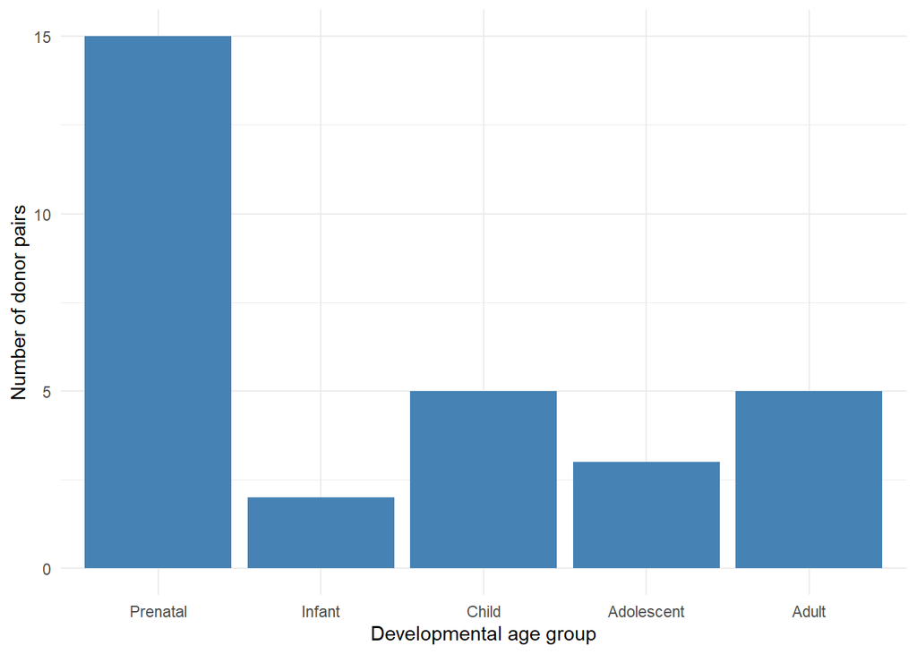

Number of matched hippocampus–DLPFC sample pairs by developmental age group.

```r
paired_counts |>
  mutate(
    age_group = factor(
      age_group,
      levels = c("Prenatal", "Infant", "Child", "Adolescent", "Adult")
    )
  ) |>
  ggplot(aes(x = age_group, y = n_pairs)) +
  geom_col(fill = "steelblue") +
  labs(
    x = "Developmental age group",
    y = "Number of donor pairs"
  ) +
  theme_minimal()
```

## Summary

The dataset includes 67 tissue samples from 37 donors across the Hippocampus and DLPFC. Of these donors, 30 contributed a sample from both regions and can be included in a paired comparison.